# Activity Monitoring Data Report

Danish Tamboli

July 19, 2020

### Check for if Zip has been Downloaded,else to download:

```r
if(!file.exists("activity_monitoring_data.zip")){
        download.file("https://d396qusza40orc.cloudfront.net/repdata%2Fdata%2Factivity.zip","activity_monitoring_data.zip")
        }
```

### Check for if Zip has been Unzipped,else to unzip:

```r
if(!file.exists("activity_monitoring_data")){
        unzip("activity_monitoring_data.zip")
        }
```

### Reading the Activity Monitoring Dataset, and having a look at how the Dataset looks:

```r
activity_data <- read.csv("activity.csv")
dim(activity_data)
```

```
## [1] 17568     3
```

```r
head(activity_data)
```

```
##   steps       date interval
## 1    NA 2012-10-01        0
## 2    NA 2012-10-01        5
## 3    NA 2012-10-01       10
## 4    NA 2012-10-01       15
## 5    NA 2012-10-01       20
## 6    NA 2012-10-01       25
```

#### We notice that there are missing Values present in the Dataset.

### Looking at the sumamry of the Dataset:

```r
summary(activity_data)
```

```
##      steps            date              interval
##  Min.   :  0.00   Length:17568       Min.   :   0.0
##  1st Qu.:  0.00   Class :character   1st Qu.: 588.8
##  Median :  0.00   Mode  :character   Median :1177.5
##  Mean   : 37.38                      Mean   :1177.5
##  3rd Qu.: 12.00                      3rd Qu.:1766.2
##  Max.   :806.00                      Max.   :2355.0
##  NA's   :2304
```

#### We notice the following:

- The Mean of the Steps taken per 5min is 37.38.
- The Date field is of character type and not date, In is in (Y-m-d) format.
- The readings have been taken at Intervals of 5 min.

#### Converting Date from class char to Date:

```r
activity_data$date <- as.Date(activity_data$date,"%Y-%d-%m")
```

#### Having a look at the Dataset once again:

```r
str(activity_data)
```

```
## 'data.frame':    17568 obs. of  3 variables:
##  $ steps   : int  NA NA NA NA NA NA NA NA NA NA ...
##  $ date    : Date, format: "2012-01-10" "2012-01-10" ...
##  $ interval: int  0 5 10 15 20 25 30 35 40 45 ...
```

#### Calculating the Total Number of steps per day:

```r
steps_datewise <- aggregate(steps~date,activity_data,sum)
```

#### Histogram of Total Number of steps per day:

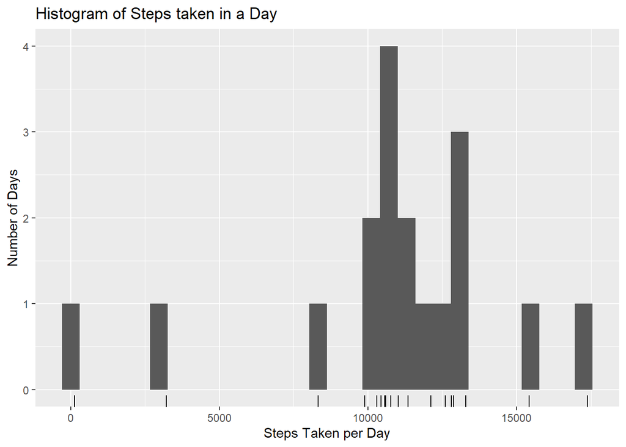

```r
library(ggplot2)
ggplot(data = steps_datewise,aes(steps)) + geom_histogram(aes(steps)) +  geom_rug(aes(steps)) + labs(x="Steps Taken per Day",y="Number of Days",title="Histogram of Steps taken in a Day")
```

#### Calculating the Mean and Median of Total steps per Day:

##### Here the Question that arises is whether to calculate the Mean and Median by

- Total Steps of Complete Duration (Which would give us per Day).
- Total Steps of Per Day (Which would give us per interval).
- We will be going with Mean and Median of Total steps over the Total Duration.

```r
total_steps <- sum(steps_datewise$steps,na.rm = TRUE)
mean_steps <- mean(steps_datewise$steps,na.rm = TRUE)
median_steps <- median(steps_datewise$steps,na.rm = TRUE)
dummydf <- data.frame(total_steps,mean_steps,median_steps)
colnames(dummydf) <- c("Total","Mean","Median")
```

##### The Total,Mean and Median are as follows:

```r
knitr::kable(dummydf)
```

| Total | Mean | Median |
| --- | --- | --- |
| 193139 | 10729.94 | 10890 |

#### Time-series Plot of Average Steps taken in Each Interval of Days over Complete Duration:

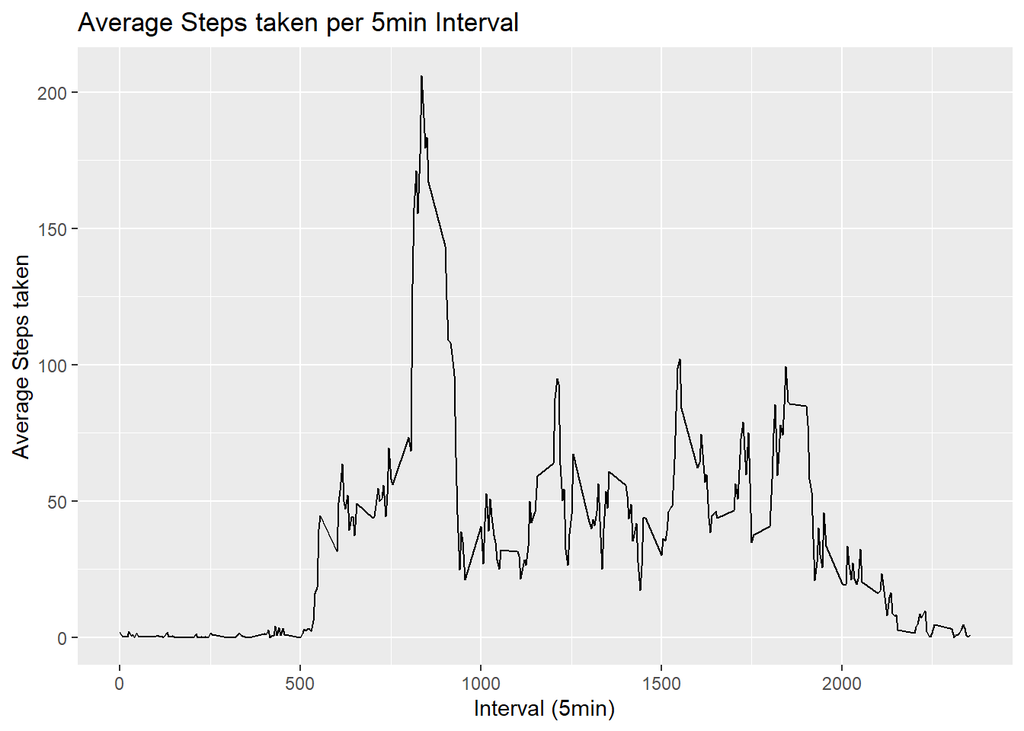

```r
average_steps_per_interval <- aggregate(steps~interval,activity_data,mean)
ggplot(data = average_steps_per_interval,aes(interval,steps)) + geom_line() + labs(x = "Interval (5min)",y = "Average Steps taken",title = "Average Steps taken per 5min Interval")
```

##### Which exact interval contains the maximum average steps?

```r
knitr::kable(average_steps_per_interval[which.max(average_steps_per_interval$steps),])
```

|  | interval | steps |
| --- | --- | --- |
| 104 | 835 | 206.1698 |

#### Missing Values:

```r
Total_NA <- sum(is.na(activity_data))
Steps_NA <- sum(is.na(activity_data[,1]))
Dates_NA <- sum(is.na(activity_data[,2]))
dummydf1 <- data.frame(Total_NA,Steps_NA,Dates_NA)
colnames(dummydf1) <- c("Total NA", "Steps NA", "Dates NA")
knitr::kable(dummydf1)
```

| Total NA | Steps NA | Dates NA |
| --- | --- | --- |
| 12960 | 2304 | 10656 |

#### Imputing the Missing Steps

```r
Steps_Na <- is.na(activity_data$steps)
Dates_Na <- is.na(activity_data$date)
new_activity_data <- activity_data
for(i in 1:nrow(new_activity_data)){
        if(is.na(new_activity_data[i,"steps"])){

                new_activity_data[i,"steps"] = average_steps_per_interval[average_steps_per_interval$interval==new_activity_data[i,"interval"],"steps"]
        }
}
head(new_activity_data)
```

```
##       steps       date interval
## 1 1.7169811 2012-01-10        0
## 2 0.3396226 2012-01-10        5
## 3 0.1320755 2012-01-10       10
## 4 0.1509434 2012-01-10       15
## 5 0.0754717 2012-01-10       20
## 6 2.0943396 2012-01-10       25
```

```r
table(is.na(new_activity_data$steps))
```

```
##
## FALSE
## 17568
```

##### The approach we have taken is to impute the missing NA Steps with the mean of Steps in that Interval over the complete duration, as we can see from the is.na check, now we have no missing values in the steps column.

#### Histogram of Total Steps in a Day after Adjusting for NA Step Values.

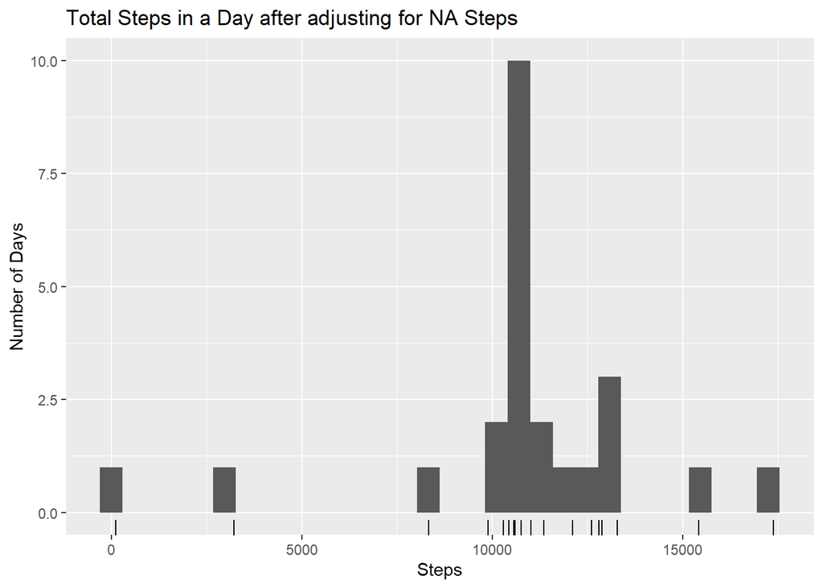

```r
new_steps_datewise <- aggregate(steps~date,new_activity_data,sum)
ggplot(data = new_steps_datewise) + geom_histogram(aes(steps)) + labs(x="Steps",y="Number of Days",title = "Total Steps in a Day after adjusting for NA Steps") + geom_rug(aes(steps))
```

#### Segregating the Days by a factor of 2 levels into Weekdays and Weekends.

```r
for(i in 1:nrow(new_activity_data)){
        if(weekdays(new_activity_data[i,"date"]) %in% c("Monday","Tuesday","Wednesday","Thursday","Friday")){
                new_activity_data[i,"Weekday"] <- "weekday"
        }
        else {
                new_activity_data[i,"Weekday"] <- "weekend"
        }
}

new_activity_data$Weekday <- as.factor(new_activity_data$Weekday)

levels(new_activity_data$Weekday)
```

```
## [1] "weekday" "weekend"
```

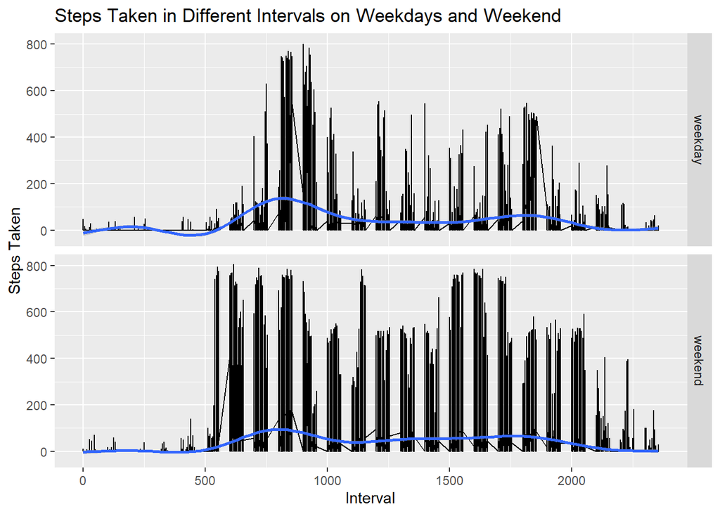

```r
ggplot(data = new_activity_data,aes(interval,steps)) + geom_line(aes(interval,steps))  + geom_smooth() + facet_grid(rows = vars(Weekday)) + labs(x= "Interval",y= "Steps Taken",title = "Steps Taken in Different Intervals on Weekdays and Weekend")
```